# 第2章 資料清理與轉換(tidyverse)

## 長資料(1行軍事投資,作業維持,人員維持,其他)轉換為寬資料(4行)

```r
library(tidyr) # spread
library(dplyr)
```

### 方法1 不使用管線操作

```r
defense_long <- select(df, Annual:Percentage)

defense_long <- select(defense_long, -c(ItemName))

# spread 表示將長資料轉換為寬資料
defense_wide <- spread(defense_long, key=Category, value=Percentage)

defense_wide
```

| Annual | 人員維持 | 作業維持 | 其他 | 軍事投資 |
| --- | --- | --- | --- | --- |
| 101 | 49.00 | 22.33 | 1.41 | 27.26 |
| 102 | 49.92 | 22.62 | 1.48 | 25.98 |
| 103 | 48.94 | 21.99 | 1.45 | 27.62 |
| 104 | 45.23 | 22.46 | 1.55 | 30.76 |
| 105 | 45.52 | 22.70 | 1.44 | 30.34 |
| 106 | 46.27 | 25.41 | 1.48 | 26.84 |
| 107 | 48.37 | 25.39 | 1.46 | 24.78 |
| 108 | 45.96 | 27.67 | NA | 26.37 |
| 109 | 47.27 | 27.22 | NA | 25.51 |
| 110 | 46.88 | 27.45 | NA | 25.67 |

[output cut: 3 more lines]

### 方法2 使用%>%

```r
defense_wide <- df %>%
  select(Annual:Percentage) %>%
  select(-c(ItemName)) %>%
  spread(key=Category, value=Percentage)

defense_wide
```

| Annual | 人員維持 | 作業維持 | 其他 | 軍事投資 |
| --- | --- | --- | --- | --- |
| 101 | 49.00 | 22.33 | 1.41 | 27.26 |
| 102 | 49.92 | 22.62 | 1.48 | 25.98 |
| 103 | 48.94 | 21.99 | 1.45 | 27.62 |
| 104 | 45.23 | 22.46 | 1.55 | 30.76 |
| 105 | 45.52 | 22.70 | 1.44 | 30.34 |
| 106 | 46.27 | 25.41 | 1.48 | 26.84 |
| 107 | 48.37 | 25.39 | 1.46 | 24.78 |
| 108 | 45.96 | 27.67 | NA | 26.37 |
| 109 | 47.27 | 27.22 | NA | 25.51 |
| 110 | 46.88 | 27.45 | NA | 25.67 |

[output cut: 3 more lines]

## 國防預算結構統計圖

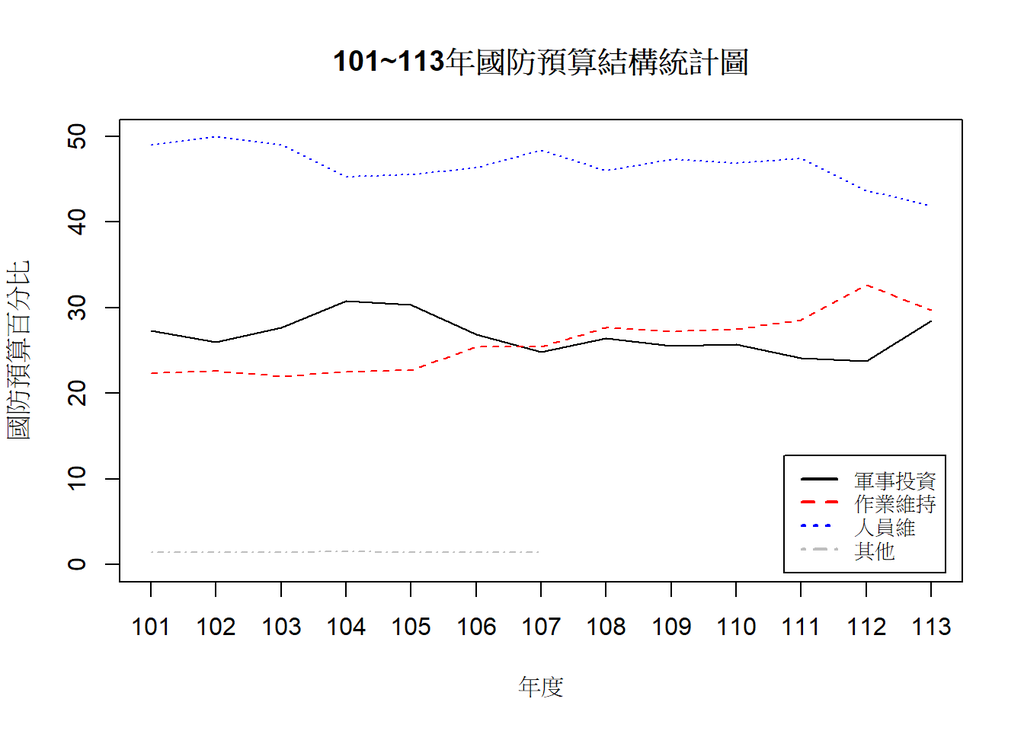

```r
plot(defense_wide$軍事投資, type="l",
     xlab="年度",
     ylab="國防預算百分比",
     main="101~113年國防預算結構統計圖",
     axes=FALSE,
     cex=0.5,
     ylim=c(0, max(defense_wide[2:5], na.rm=TRUE)))
lines(defense_wide$作業維持, col="red", lty=2)
lines(defense_wide$人員維持, col="blue", lty=3)
lines(defense_wide$其他, col="grey", lty=4)

#ind <- round(seq(1, nrow(defense_wide), length.out=5))
axis(1, at=c(1:13), labels=defense_wide$Annual)
axis(2)
legend(x="bottomright",
       inset = c(0.02, 0.02),
       legend=c("軍事投資", "作業維持", "人員維", "其他"),
       col=c("black", "red", "blue", "grey"),
       lty=c(1:4),
       lwd=2,
       cex = 0.8)
box()
```

```r
# legend(x設定值= "xxx")
# topleft    top    topright
# left       center right
# bottomleft bottom bottomright
```

- 練習使用 pivot_wider, pivot_longer {tidyr}進行長寬資料轉換

# 🌸 2.4 合併資料：join家族與鍵值設計

## 合併簡介

- tidyverse 中的 join 是資料整合（Data Joining）的核心功能，主要由 dplyr 套件提供。它可以依據一個或多個共同欄位（Key），將兩個資料框（data.frame 或 tibble）合併，功能類似 SQL 的 JOIN。
- Join 的目的通常是「將右表（第二個資料框）的欄位加入左表（第一個資料框）」。
- 共同欄位（ID）只是拿來配對，一般不會新增右表之共同欄位。
- dplyr 套件六種合併資料

| 函數 | 保留左表 | 保留右表 | 新增右表欄位 | 常見用途 |
| --- | --- | --- | --- | --- |
| inner_join() | 共同資料 | 共同資料 | ✔ | 交集分析 |
| left_join() | ✔ | 只有符合者 | ✔ | 最常用，補充欄位 |
| right_join() | 只有符合者 | ✔ | ✔ | 保留右表 |
| full_join() | ✔ | ✔ | ✔ | 完整整合資料 |
| semi_join() | ✔（符合者） | ✖ | ✖ | 篩選存在於右表的資料 |
| anti_join() | ✔（未符合者） | ✖ | ✖ | 找遺漏、異常資料 |

- 註1: semi_join() 的用途不是合併資料，而是依據右表是否存在符合條件的鍵值來篩選左表資料，因此只回傳左表原本的欄位。
- 註2: anti_join() 的目的也是篩選，只留下左表中找不到配對的列，因此同樣不會加入右表的任何欄位。

## 範例1 left_join - 左表新增右表的１個欄位

```r
library(dplyr)

students <- tibble(
  ID = c(1,2,3),
  Name = c("Alan","Bob","Cathy")
)
print("student - 左表")
```

```
## [1] "student - 左表"
```

```r
print(students)
```

```
## # A tibble: 3 × 2
##      ID Name
##   <dbl> <chr>
## 1     1 Alan
## 2     2 Bob
## 3     3 Cathy
```

```r
scores <- tibble(
  ID = c(1,2,3),
  Math = c(90,80,95)
)
print("scores - 右表")
```

```
## [1] "scores - 右表"
```

```r
print(scores)
```

```
## # A tibble: 3 × 2
##      ID  Math
##   <dbl> <dbl>
## 1     1    90
## 2     2    80
## 3     3    95
```

```r
students %>%
    left_join(scores, by = "ID")
```

| ID | Name | Math |
| --- | --- | --- |
| 1 | Alan | 90 |
| 2 | Bob | 80 |
| 3 | Cathy | 95 |

## 範例２ left_join - 左表新增右表的多個欄位

```r
scores <- tibble(
  ID = c(1,2,3),
  Math = c(90,80,95),
  English = c(88,76,91),
  Science = c(92,81,94)
)

students %>%
    left_join(scores, by="ID")
```

| ID | Name | Math | English | Science |
| --- | --- | --- | --- | --- |
| 1 | Alan | 90 | 88 | 92 |
| 2 | Bob | 80 | 76 | 81 |
| 3 | Cathy | 95 | 91 | 94 |

## 範例３ left_join - 右表的欄位找不到

```r
print(students)
```

```
## # A tibble: 3 × 2
##      ID Name
##   <dbl> <chr>
## 1     1 Alan
## 2     2 Bob
## 3     3 Cathy
```

```r
scores <- tibble(
  ID = c(1,2),
  Math = c(90,80)
)
print("scores - 右表")
```

```
## [1] "scores - 右表"
```

```r
print(scores)
```

```
## # A tibble: 2 × 2
##      ID  Math
##   <dbl> <dbl>
## 1     1    90
## 2     2    80
```

```r
# 新增結果為 NA
students %>%
    left_join(scores)
```

| ID | Name | Math |
| --- | --- | --- |
| 1 | Alan | 90 |
| 2 | Bob | 80 |
| 3 | Cathy | NA |

# 🌸 2.5 練習：完成一份可分析的乾淨資料集

## 參考Open Data 等資料，完成 Tidy Data。

## 熟悉以下資料集之資料操作

1. AirPassengers : ts 時間序列
2. Titanic : table 表格
3. airquality : data.frame 資料框
4. iris : data.frame 資料框
5. mtcars : data.frame 資料框
6. penguins : data.frame 資料框

### 1. AirPassengers 空中旅客人數資料集

- 1949-1960年航空旅客每月平均乘客數,單位:千人.
- 12年*12個月=144筆資料
- 時間序列是一組按照時間發生先後順序進行排列的資料序列.
- 通常一組時間序列的時間間隔為一固定值.
- https://github.com/rwepa/r_data_scientist/blob/main/r_training_ppt_codes_2025/r_data_science_02_r_object.R#L652

```r
?AirPassengers
```

```
## starting httpd help server ... done
```

```r
data("AirPassengers")

AirPassengers
```

```
##      Jan Feb Mar Apr May Jun Jul Aug Sep Oct Nov Dec
## 1949 112 118 132 129 121 135 148 148 136 119 104 118
## 1950 115 126 141 135 125 149 170 170 158 133 114 140
## 1951 145 150 178 163 172 178 199 199 184 162 146 166
## 1952 171 180 193 181 183 218 230 242 209 191 172 194
## 1953 196 196 236 235 229 243 264 272 237 211 180 201
## 1954 204 188 235 227 234 264 302 293 259 229 203 229
## 1955 242 233 267 269 270 315 364 347 312 274 237 278
## 1956 284 277 317 313 318 374 413 405 355 306 271 306
## 1957 315 301 356 348 355 422 465 467 404 347 305 336
## 1958 340 318 362 348 363 435 491 505 404 359 310 337
## 1959 360 342 406 396 420 472 548 559 463 407 362 405
## 1960 417 391 419 461 472 535 622 606 508 461 390 432
```

```r
class(AirPassengers) # ts
```

```
## [1] "ts"
```

```r
length(AirPassengers)
```

```
## [1] 144
```

```r
str(AirPassengers)
```

```
##  Time-Series [1:144] from 1949 to 1961: 112 118 132 129 121 135 148 148 136 119 ...
```

```r
summary(AirPassengers)
```

```
##    Min. 1st Qu.  Median    Mean 3rd Qu.    Max.
##   104.0   180.0   265.5   280.3   360.5   622.0
```

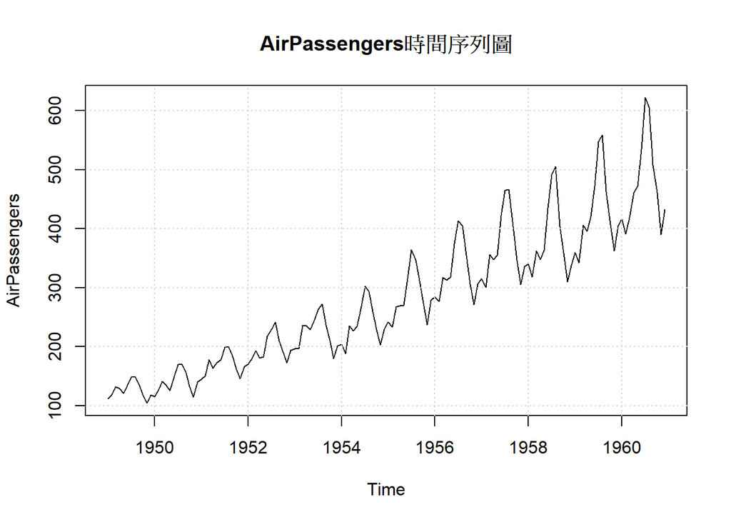

```r
# 繪製 ts 資料
plot(AirPassengers, main="AirPassengers時間序列圖")
grid()
```

```r
# 找出樣式 (Patterns)
```

### 2. Titanic 1912年鐵達尼號資料集

```r
# ?Titanic

data(Titanic)

Titanic # Titanic 不是 data.frame, 而是一個四維列聯表 (Contingency Table)
```

```
## , , Age = Child, Survived = No
##
##       Sex
## Class  Male Female
##   1st     0      0
##   2nd     0      0
##   3rd    35     17
##   Crew    0      0
##
## , , Age = Adult, Survived = No
##
##       Sex
## Class  Male Female
##   1st   118      4
##   2nd   154     13
##   3rd   387     89
##   Crew  670      3
##
## , , Age = Child, Survived = Yes
##
##       Sex
## Class  Male Female
##   1st     5      1
##   2nd    11     13
##   3rd    13     14
##   Crew    0      0
##
## , , Age = Adult, Survived = Yes
##
##       Sex
## Class  Male Female
##   1st    57    140
##   2nd    14     80
##   3rd    75     76
##   Crew  192     20
```

```r
class(Titanic) # table
```

```
## [1] "table"
```

```r
sum(Titanic) # 總人數
```

```
## [1] 2201
```

```r
# 物件結構, 有4個維度(列: Class, 行: Sex, 第3維度: Age, 第4維度: Survived)
# 4*2*2*2 = 32 種組合
str(Titanic)
```

```
##  'table' num [1:4, 1:2, 1:2, 1:2] 0 0 35 0 0 0 17 0 118 154 ...
##  - attr(*, "dimnames")=List of 4
##   ..$ Class   : chr [1:4] "1st" "2nd" "3rd" "Crew"
##   ..$ Sex     : chr [1:2] "Male" "Female"
##   ..$ Age     : chr [1:2] "Child" "Adult"
##   ..$ Survived: chr [1:2] "No" "Yes"
```

```r
summary(Titanic)
```

```
## Number of cases in table: 2201
## Number of factors: 4
## Test for independence of all factors:
##  Chisq = 1637.4, df = 25, p-value = 0
##  Chi-squared approximation may be incorrect
```

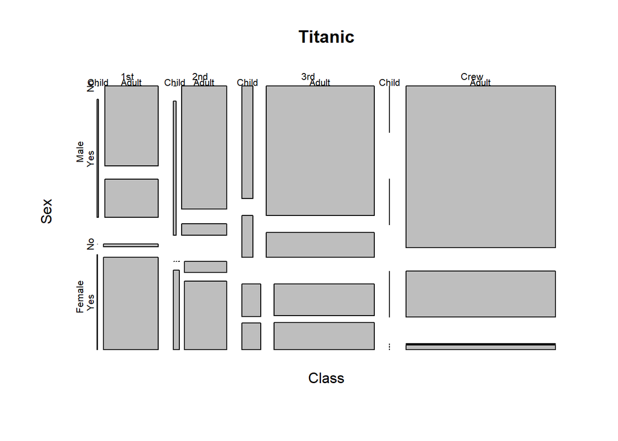

```r
# 繪製 table 資料
# Mosaic Plot (馬賽克圖)是一種專門用來呈現多維類別資料 (Multivariate Categorical Data)的圖形.
# 馬賽克圖用來呈現32種組合的人數. 矩形越大, 代表該組合的人數越多.
# Crew > 3rd (三等艙) > 1st(頭等艙) > 2nd(二等艙)
plot(Titanic)
```

```r
# 兒童存活率較高嗎？
apply(Titanic, c(3, 4), sum)
```

```
##        Survived
## Age       No Yes
##   Child   52  57
##   Adult 1438 654
```

```r
# 女性的存活率更高？
apply(Titanic, c(2, 4), sum)
```

```
##         Survived
## Sex        No Yes
##   Male   1364 367
##   Female  126 344
```

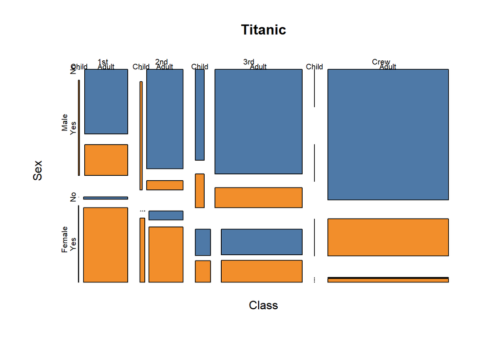

```r
# 使用 mosaicplot() 自訂顏色
mosaicplot(
  Titanic,
  color = c(
    "#4E79A7",  # 藍
    "#F28E2B",  # 橘
    "#59A14F",  # 綠
    "#E15759",  # 紅
    "#76B7B2",  # 青
    "#EDC948",  # 黃
    "#B07AA1",  # 紫
    "#FF9DA7"   # 粉
  ),
  main = "Titanic",
  xlab = "Class",
  ylab = "Sex"
)
```